# IODS course project

Maria Zubair

# Week 1 - Start me up!

I came to know about **Introduction to Open Data Science** course from a friend and immediately signed up for it. I think this course will be a *great learning experience* for me.

You can find my my GitHub repository [here](https://github.com/zmariaa/IODS-project/).

# Week 2 - Regression and model validation

## Part 1

**Step 1** - Reading data from the local folder as prepared in data wrangling exercise. You can find the code in data folder.

We use *head()* to check if data is loaded correctly.

```r
data <- read.csv(file = "data/learning2014.csv", row.names = 1)
head(data)
```

```
##   gender age attitude     deep  stra     surf points
## 1      F  53      3.7 3.583333 3.375 2.583333     25
## 2      M  55      3.1 2.916667 2.750 3.166667     12
## 3      F  49      2.5 3.500000 3.625 2.250000     24
## 4      M  53      3.5 3.500000 3.125 2.250000     10
## 5      M  49      3.7 3.666667 3.625 2.833333     22
## 6      F  38      3.8 4.750000 3.625 2.416667     21
```

**Step 2** : Exploring the dimensions and basic structure of data using *dim()* and *str()* respectively.

```r
dim(data)
```

```
## [1] 166   7
```

The output of *dim()* shows that there are 166 observations and 7 variables in the analysis dataset.

```r
str(data)
```

```
## 'data.frame':    166 obs. of  7 variables:
##  $ gender  : Factor w/ 2 levels "F","M": 1 2 1 2 2 1 2 1 2 1 ...
##  $ age     : int  53 55 49 53 49 38 50 37 37 42 ...
##  $ attitude: num  3.7 3.1 2.5 3.5 3.7 3.8 3.5 2.9 3.8 2.1 ...
##  $ deep    : num  3.58 2.92 3.5 3.5 3.67 ...
##  $ stra    : num  3.38 2.75 3.62 3.12 3.62 ...
##  $ surf    : num  2.58 3.17 2.25 2.25 2.83 ...
##  $ points  : int  25 12 24 10 22 21 21 31 24 26 ...
```

The output of *str()* shows that there are 166 observations of the 7 variables. It shows the details about each of the variable including the name, type and some values. The analysis dataset was created using meta data of JYTOPKYS3. The [original data](https://www.mv.helsinki.fi/home/kvehkala/JYTmooc/JYTOPKYS3-data.txt) used was collected in 2014-2015 using surveys and contained 60 variables.

The idea of this analysis is to study 3 learning approaches/strategies: deep, strategic and surface.

Below is a brief overview of the variables:

- **gender**: is a factor type with two distinct values: “F” and “M”
- **age**: age is in years and it is dervice from the date of birth.
- **attitude**: is the scaled back (mean) values of 10 questions related to students attitude towards statistics.
- **deep**: It contains the mean values of questions in the survey which were related to deep learning approach.
- **stra**: It contains the mean values of questions in the survey which were related to strategic learning approach.
- **surf**: It contains the mean values of questions in the survey which were related to surface learning approach.
- **points**: It contains the scores of students on statistics course exam.

## Part 2

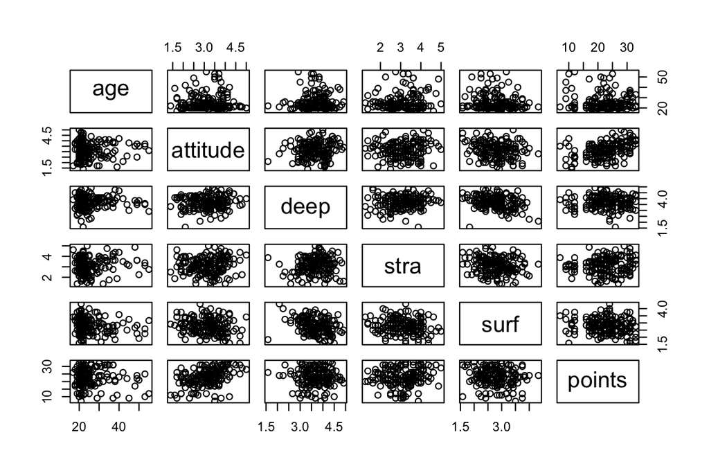

```r
library(ggplot2)
library(GGally)
pairs(data[-1])
```

```r
p <- ggpairs(data, mapping = aes(), lower = list(combo = wrap("facethist", bins = 20)))
```

Using this scatter plot matrix we can observe the distribution of variables and their relationships. For example, observing age, which is represented in first row and first column, we can see that the distribution shows that most of the participants are young (less than 30). We can also observe relations, for example, points and attitude show a clear relationship that as attitude value increases, points increase as well.

We can also analyze individual distributions in detail using *hist()*.

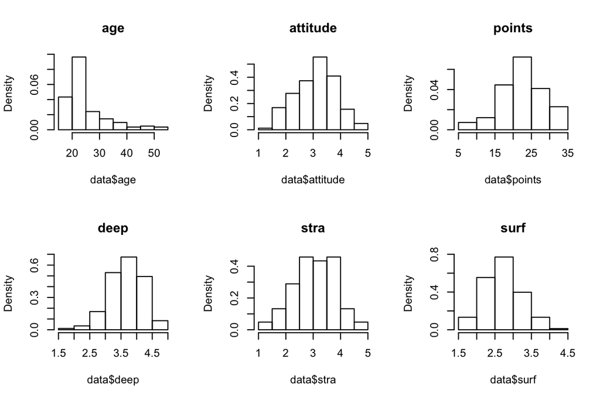

```r
par(mfrow=c(2,3))
hist(data$age, prob=T, main="age")
hist(data$attitude, prob=T, main="attitude")
hist(data$points, prob=T, main="points")
hist(data$deep, prob=T, main="deep")
hist(data$stra, prob=T, main="stra")
hist(data$surf, prob=T, main="surf")
```

Another graphical summary tools is boxplot. One meaningful way to use it here will be to visualize scores of 3 learning methods for a quick comparison.

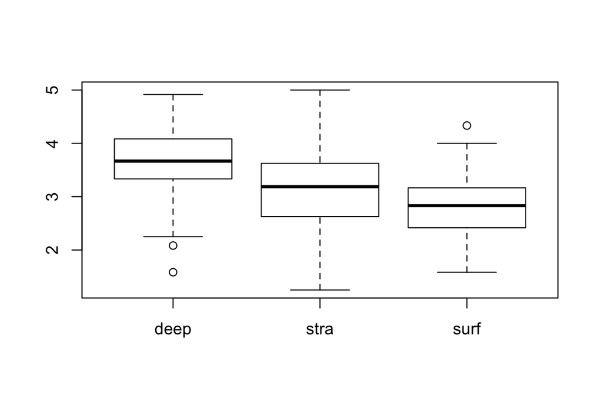

```r
boxplot(data[,4:6])
```

## Part 3

```r
my_model <- lm(points ~ attitude + age + deep, data)
summary(my_model)
```

```
##
## Call:
## lm(formula = points ~ attitude + age + deep, data = data)
##
## Residuals:
##     Min      1Q  Median      3Q     Max
## -17.206  -3.430   0.204   3.979  10.950
##
## Coefficients:
##             Estimate Std. Error t value Pr(>|t|)
## (Intercept) 15.60773    3.38966   4.605 8.32e-06 ***
## attitude     3.59413    0.56959   6.310 2.56e-09 ***
## age         -0.07716    0.05322  -1.450    0.149
## deep        -0.60275    0.75031  -0.803    0.423
## ---
## Signif. codes:  0 '***' 0.001 '**' 0.01 '*' 0.05 '.' 0.1 ' ' 1
##
## Residual standard error: 5.307 on 162 degrees of freedom
## Multiple R-squared:  0.2043, Adjusted R-squared:  0.1896
## F-statistic: 13.87 on 3 and 162 DF,  p-value: 4.305e-08
```

Looking at the p-value of the F-statistic and t-statitic values in the coefficient table, it seems there is a significant association between points and attitude. In comparison to that, age and deep learning strateft have a weaker association with earned points in the exam.

We can check the confidence interval of the model using *confint()*.

```r
confint(my_model)
```

```
##                  2.5 %      97.5 %
## (Intercept)  8.9141112 22.30135604
## attitude     2.4693631  4.71890284
## age         -0.1822595  0.02794462
## deep        -2.0843976  0.87889331
```

```r
my_model <- lm(points ~ attitude + deep, data)
summary(my_model)
```

```
##
## Call:
## lm(formula = points ~ attitude + deep, data = data)
##
## Residuals:
##      Min       1Q   Median       3Q      Max
## -16.8463  -3.2975   0.2789   4.1213  11.1399
##
## Coefficients:
##             Estimate Std. Error t value Pr(>|t|)
## (Intercept)  13.7812     3.1574   4.365 2.25e-05 ***
## attitude      3.5780     0.5714   6.262 3.25e-09 ***
## deep         -0.6275     0.7526  -0.834    0.406
## ---
## Signif. codes:  0 '***' 0.001 '**' 0.01 '*' 0.05 '.' 0.1 ' ' 1
##
## Residual standard error: 5.325 on 163 degrees of freedom
## Multiple R-squared:  0.194,  Adjusted R-squared:  0.1841
## F-statistic: 19.62 on 2 and 163 DF,  p-value: 2.326e-08
```

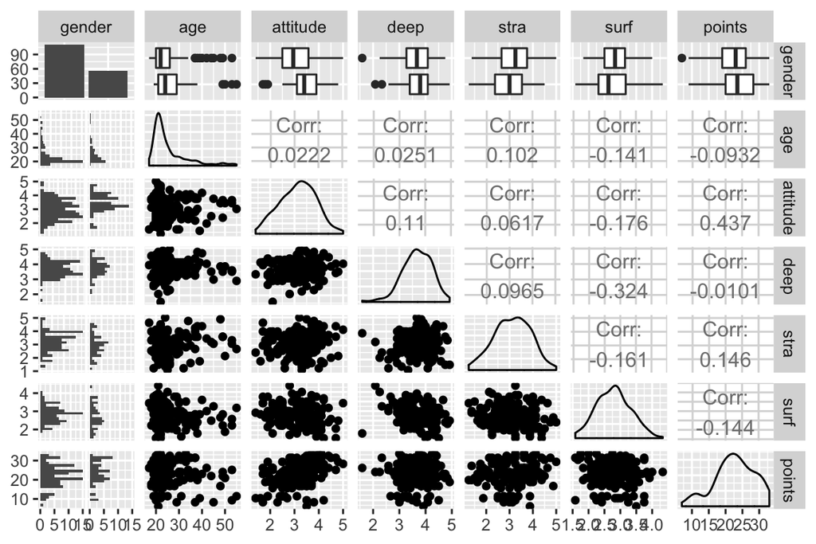

```r
ggpairs(data, lower = list(combo = wrap("facethist", bins = 20)))
```

## Part 4

Analysis: From the summary and charts shows in part 3, below observations can be made:

- Attitude has the most significant relation with points as compared to other two factors.
- As this is a case of multiple regression, so R2 increases as more variables are added. Therefore, we consider the adjusted R2, and its value (around 0.18) suggests that although attitude is a significant factor but it is not the only factor influencing points.

## Part 5

```r
my_model <- lm(points ~ attitude + age + deep, data)
par(mflow=c(2,2))
```

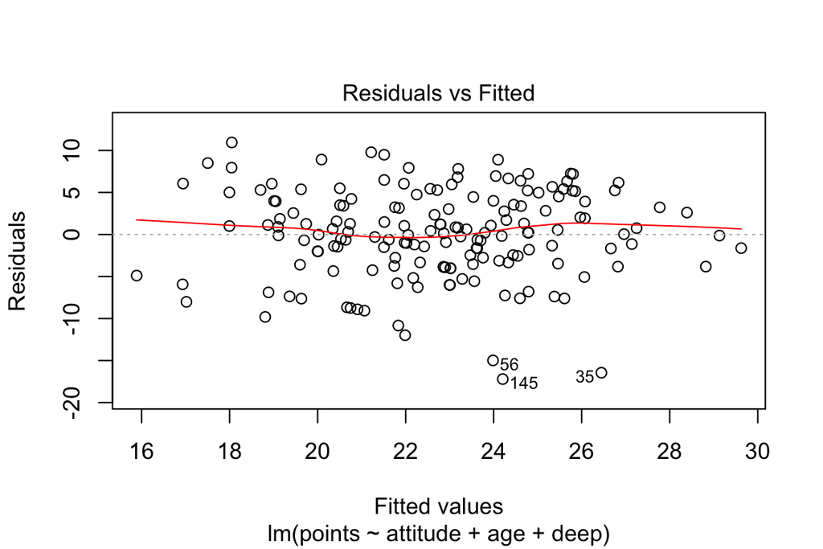

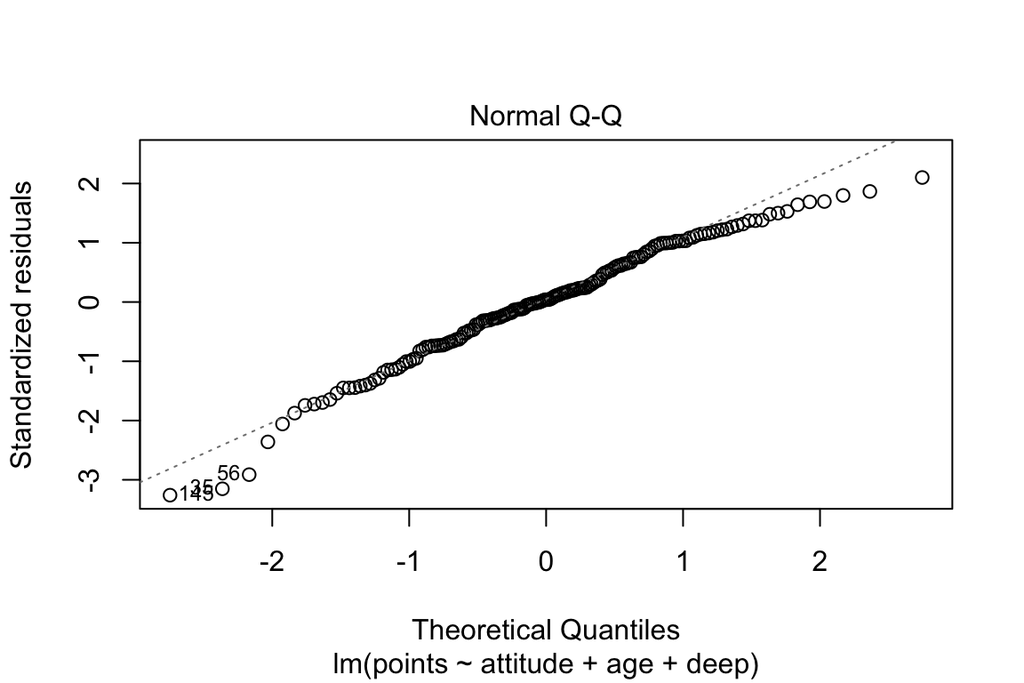

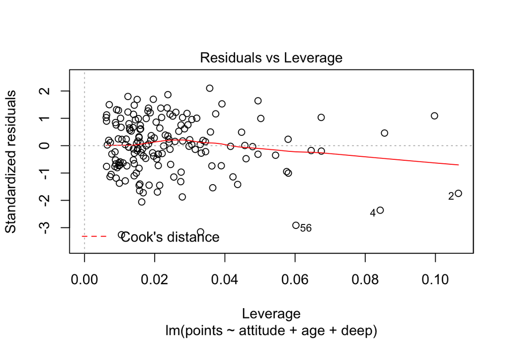

```r
plot(my_model, which=c(1,2,5))
```

Model assumption: There is a linear correlation between variables and errors are normally distributed.

Observations:

1. Residuals vs Fitted (1): The plot confirms the linear correlations.
2. Normal Q-Q (2): There is a clear pattern indicating errors are normally distributed with a clear exception of very low or very high values.
3. Residuals vs Leverage: The plot is skewed and it can be said that there are no observations (outliers) which stand out significantly (or has unusually hight leverage on data).

# Week 3 - Logistic Regression - Analysis

## Part 2

```r
alc <- read.csv( file="data/alc.csv", sep=",")
dim(alc)
```

```
## [1] 382  35
```

```r
colnames(alc)
```

```
##  [1] "school"     "sex"        "age"        "address"    "famsize"
##  [6] "Pstatus"    "Medu"       "Fedu"       "Mjob"       "Fjob"
## [11] "reason"     "nursery"    "internet"   "guardian"   "traveltime"
## [16] "studytime"  "failures"   "schoolsup"  "famsup"     "paid"
## [21] "activities" "higher"     "romantic"   "famrel"     "freetime"
## [26] "goout"      "Dalc"       "Walc"       "health"     "absences"
## [31] "G1"         "G2"         "G3"         "alc_use"    "high_use"
```

This data is combined from two data-sets containing responses of student performance questionnaire from math and portuguese classes. This joined data (of students who answered for both questionnaires) has 382 observations of 35 variables. The name of variables can be seen in the output above. The details on original variables collected from questionnaire can be found [here](https://archive.ics.uci.edu/ml/datasets/Student+Performance). The additional attributes added are:

- alc_use: combines weekly and weekend alocohol use levels (Dalc and Walc).
- hight_use: logical column where True value represents that alc_use > 2, otherwise false.

## Part 3

The 4 interesting variables in relation to alochol consumption for my analysis are:

- famrel: quality of family relationships (numeric: from 1 - very bad to 5 - excellent)
- studytime: weekly study time (numeric: 1 - <2 hours, 2 - 2 to 5 hours, 3 - 5 to 10 hours, or 4 - >10 hours)
- freetime: free time after school (numeric: from 1 - very low to 5 - very high)
- goout: going out with friends (numeric: from 1 - very low to 5 - very high)

These variables are chosen to see overall impact of time management on the alcohol consumption. My hypothesis is that if students have **more** meaningless time (higher values for freetime and goout) and **less** meaningful time (time spent with family and studying), their alochol consumption will be high.

## Part 4

Let’s first see the distributions:

```r
library(dplyr)
```

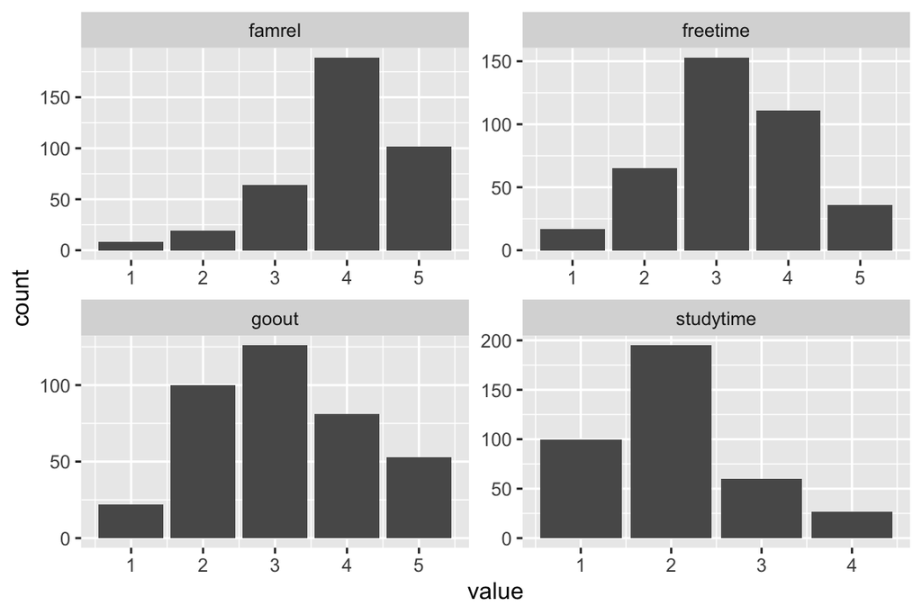

```r
library(tidyr)
library(ggplot2)
alc_selected <- select(alc, one_of(c("freetime", "famrel", "studytime", "goout")))
gather(alc_selected) %>% ggplot(aes(value)) + facet_wrap("key", scales = "free") + geom_bar()
```

The distributions are skewed. The skewness can be interpreted as:

- Mostly students probably spent more time with family as family relations are strong for most of the students.
- Most of the students have a medium or medium-high free time. Only a small propotion have very low free time (1).
- Most of the students have a medium or medium-low frequency of going out with friends.
- Mostly students spent 2-5 hours in studying.

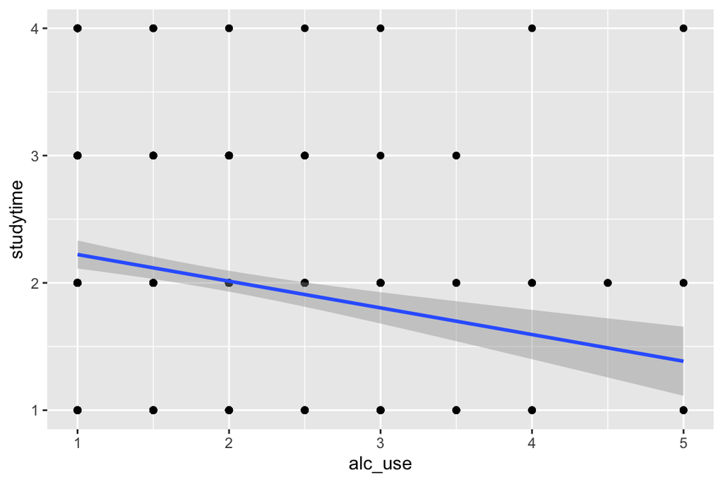

```r
qplot(alc_use, studytime, data = alc) + geom_smooth(method = "lm")
```

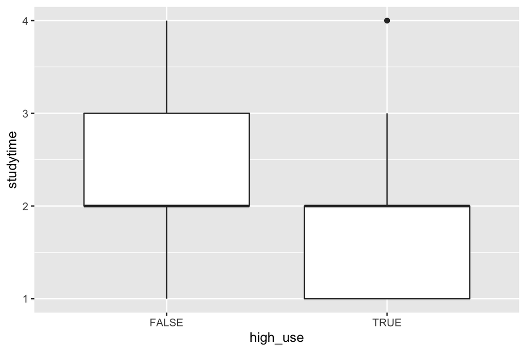

```r
g1 <- ggplot(alc, aes(x = high_use, y = studytime))
g1 + geom_boxplot() + ylab("studytime")
```

**Interpretation of studytime**: Alcohol use increases as the studytime decreases.

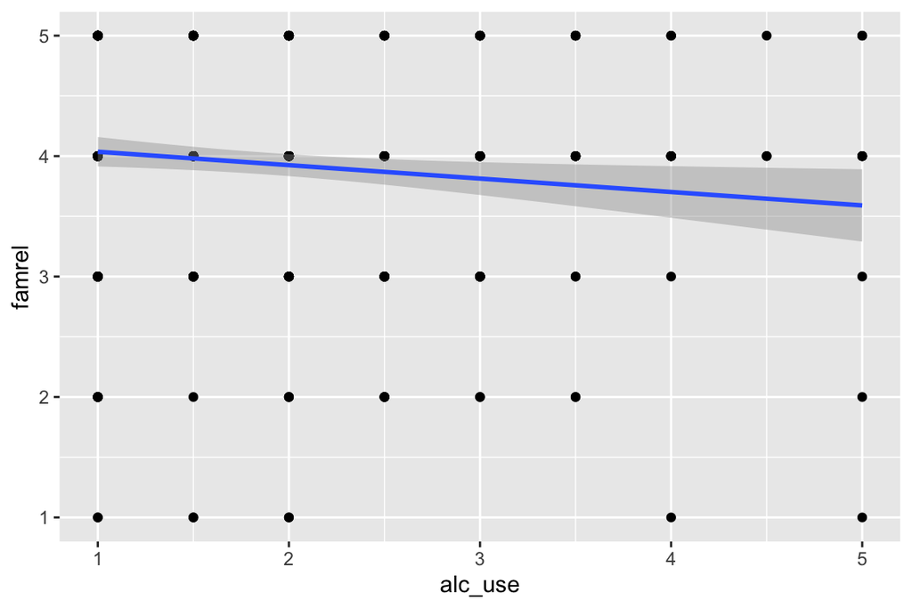

```r
qplot(alc_use, famrel, data = alc) + geom_smooth(method = "lm")
```

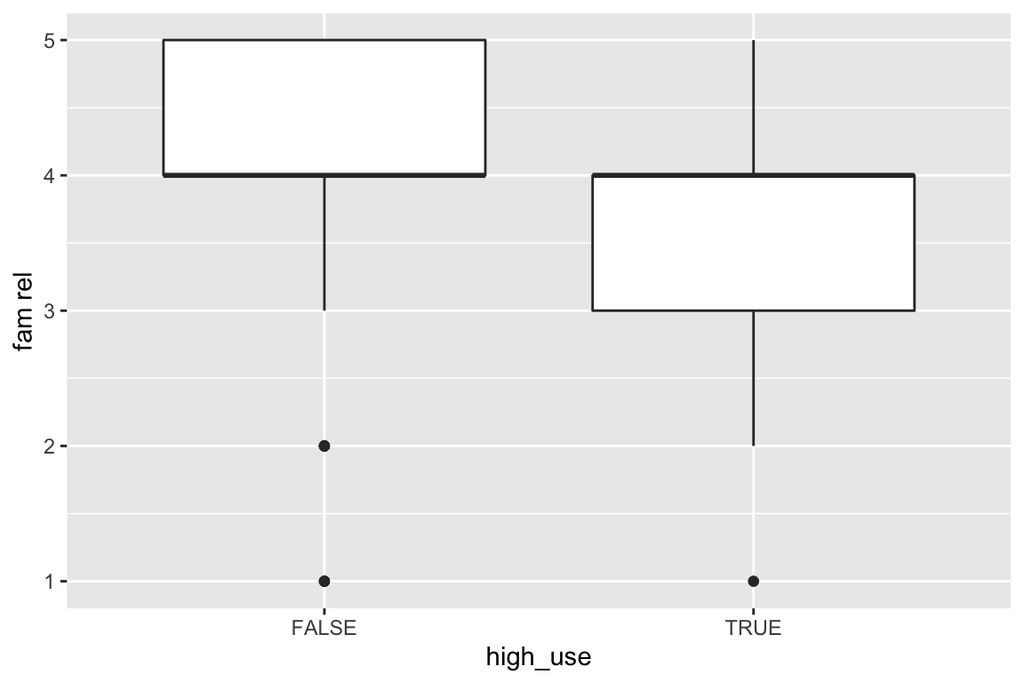

```r
g1 <- ggplot(alc, aes(x = high_use, y = famrel))
g1 + geom_boxplot() + ylab("fam rel")
```

**Interpretation of famrel**: Alcohol use increases as the fam-rel strength decreases.

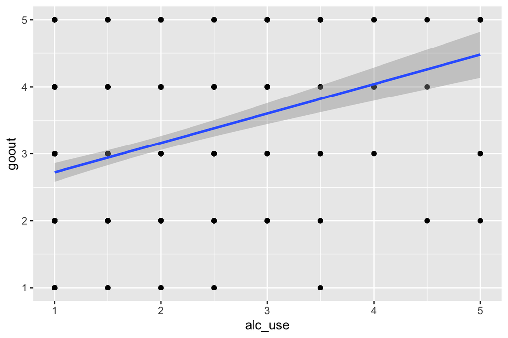

```r
qplot(alc_use, goout, data = alc) + geom_smooth(method = "lm")
```

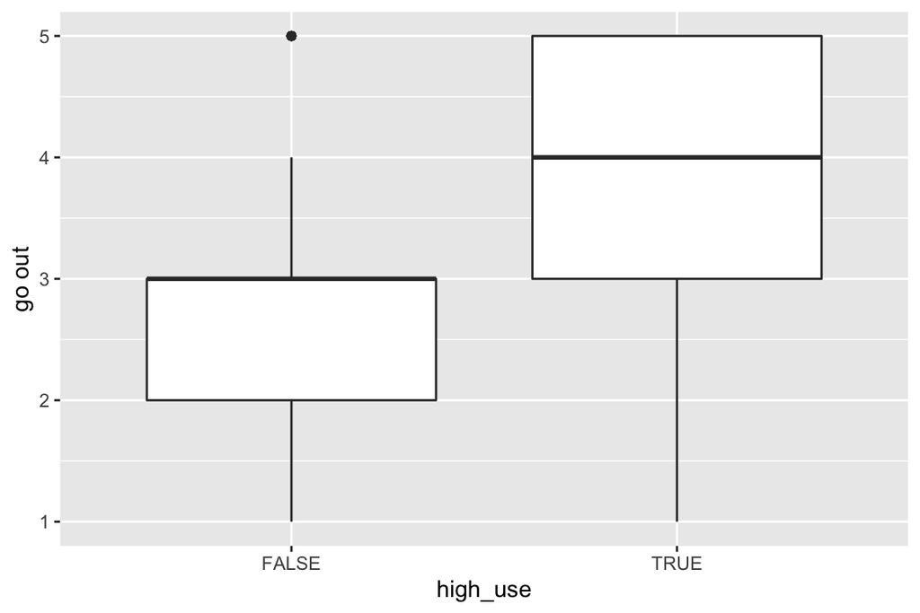

```r
g1 <- ggplot(alc, aes(x = high_use, y = goout))
g1 + geom_boxplot() + ylab("go out")
```

**Interpretation of goout**: Alcohol use increases as the going out with friends activity increases.

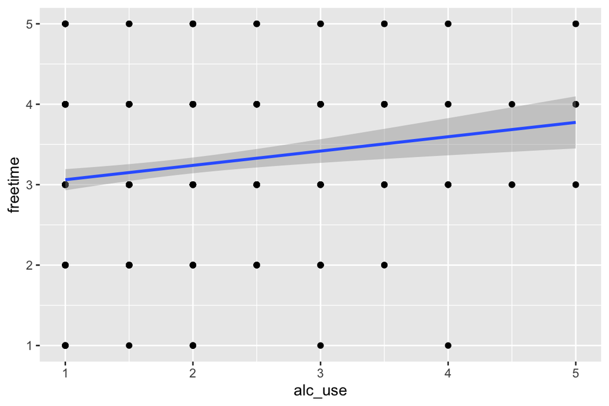

```r
qplot(alc_use, freetime, data = alc) + geom_smooth(method = "lm")
```

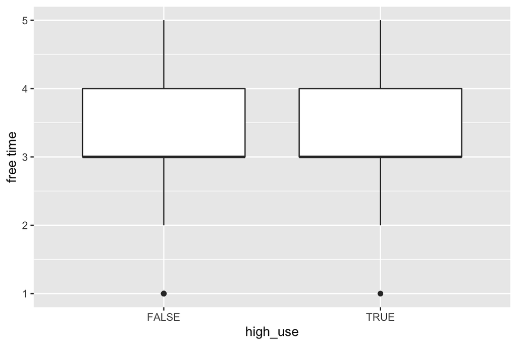

```r
g1 <- ggplot(alc, aes(x = high_use, y = freetime))
g1 + geom_boxplot() + ylab("free time")
```

**Interpretation of freetime**: Alcohol use increases as the freetime increases but the change is not significant.

## Part 5

Use logistic regression to statistically explore the relationship between your chosen variables and the binary high/low alcohol consumption variable as the target variable. Present and interpret a summary of the fitted model. Present and interpret the coefficients of the model as odds ratios and provide confidence intervals for them. Interpret the results and compare them to your previously stated hypothesis. Hint: If your model includes factor variables see for example the first answer of this stackexchange thread on how R treats and how you should interpret these variables in the model output (or use some other resource to study this). (0-5 points)

```r
m <- glm(high_use ~ studytime + famrel + freetime + goout, data = alc, family = "binomial")
summary(m)
```

```
##
## Call:
## glm(formula = high_use ~ studytime + famrel + freetime + goout,
##     family = "binomial", data = alc)
##
## Deviance Residuals:
##     Min       1Q   Median       3Q      Max
## -1.8641  -0.7799  -0.5462   0.8654   2.6080
##
## Coefficients:
##             Estimate Std. Error z value Pr(>|z|)
## (Intercept)  -1.1360     0.7523  -1.510 0.131010
## studytime    -0.5805     0.1659  -3.498 0.000468 ***
## famrel       -0.3732     0.1372  -2.720 0.006537 **
## freetime      0.1273     0.1358   0.938 0.348413
## goout         0.7487     0.1227   6.100 1.06e-09 ***
## ---
## Signif. codes:  0 '***' 0.001 '**' 0.01 '*' 0.05 '.' 0.1 ' ' 1
##
## (Dispersion parameter for binomial family taken to be 1)
##
##     Null deviance: 465.68  on 381  degrees of freedom
## Residual deviance: 393.03  on 377  degrees of freedom
## AIC: 403.03
##
## Number of Fisher Scoring iterations: 4
```

```r
OR <- coef(m) %>% exp
CI <- confint(m) %>% exp
cbind(OR, CI)
```

```
##                    OR      2.5 %    97.5 %
## (Intercept) 0.3211022 0.07177448 1.3833352
## studytime   0.5596279 0.40001439 0.7681441
## famrel      0.6885197 0.52460597 0.9003017
## freetime    1.1357556 0.87062313 1.4846514
## goout       2.1142144 1.67292633 2.7096221
```

## Part 6

```r
probabilities <- predict(m, type = "response")

alc <- mutate(alc, probability = probabilities)

alc <- mutate(alc, prediction = probability > 0.5)

prediction_results <- table(high_use = alc$high_use, prediction = alc$prediction)
prediction_results
```

```
##         prediction
## high_use FALSE TRUE
##    FALSE   246   22
##    TRUE     72   42
```

Graphical representation:

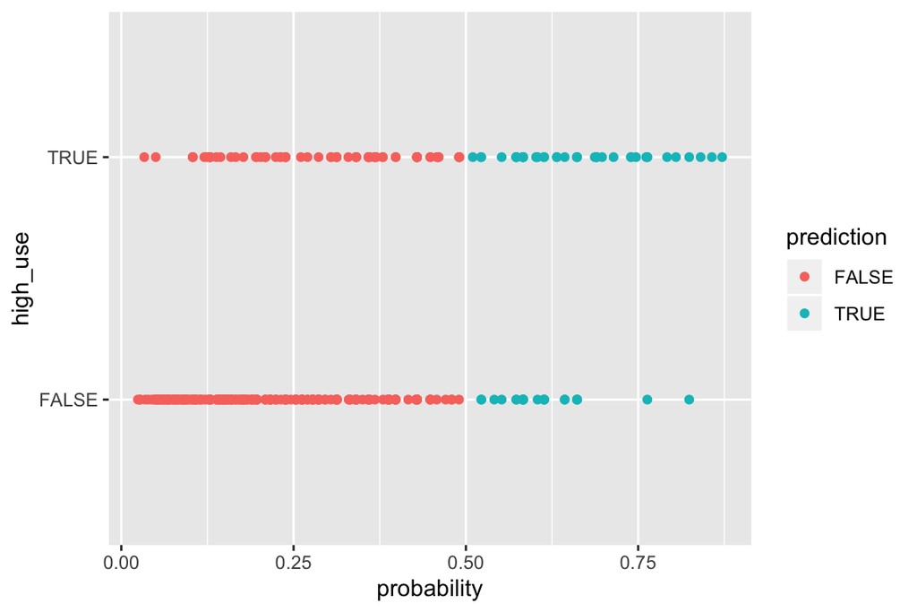

```r
g <- ggplot(alc, aes(x = probability, y = high_use, col = prediction))
g + geom_point()
```

```r
results <- table(high_use = alc$high_use, prediction=alc$prediction)%>%prop.table%>%addmargins

results
```

```
##         prediction
## high_use      FALSE       TRUE        Sum
##    FALSE 0.64397906 0.05759162 0.70157068
##    TRUE  0.18848168 0.10994764 0.29842932
##    Sum   0.83246073 0.16753927 1.00000000
```

These results show that 0.7539267 or 75% (64.38% FALSE and 10.99% TRUE) results are correctly predicted and approximately 25% of the results (5.75% TRUE and 18.84% False) are incorrectly predicted. Thus, the prediction power is quite good as compared to simple guessing (50% chance of getting right).